# Loading and manipulating XRPD data

This document will use **powdR** and the open-source X-ray powder diffraction (XRPD) data within it to provide reproducible examples of:

1. Loading XRPD data
2. Plotting XRPD data
3. Manipulating XRPD data

# 1 Loading XRPD data

[video not shown]

In order to work with XRPD data in R, it first needs to be loaded. XRPD data come in all sorts of proprietary formats (e.g. .raw, .dat and .xrdml), which can make this initial stage of loading data more complicated than it needs to be. In its most basic form, XRPD data is simply comprised of an x-axis (2θ) and y-axis (counts), and all XRPD data loaded into R throughout this documentation will take this XY form. Here, 2 ways of loading proprietary XRPD data into R will be described.

## 1.1 Option 1: PowDLL

The free software [PowDLL](http://users.uoi.gr/nkourkou/powdll/) offers excellent features for the conversion of different XRPD file types. PowDLL can read a large range of XRPD file types and export them in many formats that include ‘.xy’ files. These ‘.xy’ files are an ASCII format that simply comprises the two variables (2θ and counts) separated by a space. [This video from Phys Whiz on YouTube](https://www.youtube.com/watch?v=YUxg4-D-1Bk&feature=emb_title) illustrates the use of powDLL to create ‘.xy’ files.

Once you have your ‘.xy’ files, they can be loaded into R using the `read_xy()` function from **powdR**. The following reproducible example uses files that are stored within **powdR** and were recorded on a Siemens D5000 using Co-Kα radiation.

```r
library(powdR)

#Extract the path of an xy file from the powdR package
file <- system.file("extdata/D5000/xy/D5000_1.xy", package = "powdR")

#Load the file as an object called xy1
xy1 <- read_xy(file)
```

```r
#Explore the xy data
summary(xy1)
```

```
#>       tth            counts
#>  Min.   : 2.00   Min.   :  70.0
#>  1st Qu.:20.25   1st Qu.: 145.0
#>  Median :38.50   Median : 236.0
#>  Mean   :38.50   Mean   : 292.9
#>  3rd Qu.:56.75   3rd Qu.: 342.0
#>  Max.   :75.00   Max.   :6532.0
```

```r
#check the class of xy data
class(xy1)
```

```
#> [1] "XY"         "data.frame"
```

Notice how the class of `xy1` is both `XY` and `data.frame`. This means that various additional methods for each of these types of object classes can be used to explore and analyse the data. These methods can be viewed using:

```r
methods(class = "XY")
```

```
#> [1] align_xy    interpolate plot
#> see '?methods' for accessing help and source code
```

which shows how functions `align_xy()`, `interpolate()` and `plot()` all have methods for `XY` class objects. Help on each of these can be sourced using `?align_xy.XY`, `?interpolate.XY` and `?plot.XY`, respectively. When calling these functions it is not necessary to specify the `.XY` suffix because R will recognise the class and call the relevant method.

## 1.2 Option 2: Loading directly into R

Alternatively to PowDLL, the `extract_xy()` function in the **powdR** package can extract the XY data from a wide range of proprietary XRPD files straight into R via the `xylib` C++ library implemented behind the scenes in the **rxylib** package (Kreutzer and Johannes Friedrich 2020).

```r
#Extract the path of the file from the powdR package
file <- system.file("extdata/D5000/RAW/D5000_1.RAW", package = "powdR")

#Load the file as an object called xy2
xy2 <- extract_xy(file)
```

```
#>
#> [read_xyData()] >> File of type Siemens/Bruker RAW detected
```

```r
#Summarise the xy data
summary(xy2)
```

```
#>       tth            counts
#>  Min.   : 2.00   Min.   :  70.0
#>  1st Qu.:20.25   1st Qu.: 145.0
#>  Median :38.50   Median : 236.0
#>  Mean   :38.50   Mean   : 292.9
#>  3rd Qu.:56.75   3rd Qu.: 342.0
#>  Max.   :75.00   Max.   :6532.0
```

```r
#Check the class of xy2
class(xy2)
```

```
#> [1] "XY"         "data.frame"
```

A **word of warning** with `extract_xy()` is that it does not work with all proprietary file types. In particular, you may experience problems with Bruker ‘.raw’ files, in which case the use of PowDLL outlined above is recommended instead.

## 1.3 Loading multiple files

The two approaches for loading XRPD data outlined above can also be used to load any number of files into R at once. `read_xy()` and `extract_xy()` will recognise cases where more than one file path is supplied and therefore load the files into a `multiXY` object.

### 1.3.1 `read_xy()`

There are five ‘.xy’ files stored within a directory of the **powdR** package that can be loaded into a `multiXY` object via:

```r
#Extract the paths of the files
paths1 <- dir(system.file("extdata/D5000/xy", package = "powdR"),
             full.names = TRUE)

#Now read all files
xy_list1 <- read_xy(paths1)

#Check the class of xy_list1
class(xy_list1)
```

```
#> [1] "multiXY" "list"
```

The resulting `multiXY` object is a list of `XY` objects, with each `XY` object being a data frame comprised of the 2θ and count intensities of the XRPD data.

```r
#Check the class of each item within the multiXY object
lapply(xy_list1, class)
```

```
#> $D5000_1
#> [1] "XY"         "data.frame"
#>
#> $D5000_2
#> [1] "XY"         "data.frame"
#>
#> $D5000_3
#> [1] "XY"         "data.frame"
#>
#> $D5000_4
#> [1] "XY"         "data.frame"
#>
#> $D5000_5
#> [1] "XY"         "data.frame"
```

Each sample within the list can be accessed using the `$` symbol. For example:

```r
#Summarise the data within the first sample:
summary(xy_list1$D5000_1)
```

```
#>       tth            counts
#>  Min.   : 2.00   Min.   :  70.0
#>  1st Qu.:20.25   1st Qu.: 145.0
#>  Median :38.50   Median : 236.0
#>  Mean   :38.50   Mean   : 292.9
#>  3rd Qu.:56.75   3rd Qu.: 342.0
#>  Max.   :75.00   Max.   :6532.0
```

Alternatively, the `D5000_1` item within `xy_list1` could be accessed using `xy_list1[[1]]`. In the same way that `XY` class objects have methods associated with them, there are a number of different methods for `multiXY` objects:

```r
methods(class = "multiXY")
```

```
#> [1] align_xy       interpolate    multi_xy_to_df plot
#> see '?methods' for accessing help and source code
```

which include `align_xy()`, `interpolate()`, `multi_xy_to_df()` and `plot` that are all detailed in subsequent sections.

### 1.3.2 `extract_xy()`

In addition to the five ‘.xy’ files loaded above, there are also five ‘.RAW’ files stored within a separate directory of **powdR**, which can be loaded in a similar fashion using `extract_xy()`:

```r
#Extract the paths of the files
paths2 <- dir(system.file("extdata/D5000/RAW", package = "powdR"),
              full.names = TRUE)

#Now read all files in the directory
xy_list2 <- extract_xy(paths2)
```

```
#>
#> [read_xyData()] >> File of type Siemens/Bruker RAW detected
#>
#> [read_xyData()] >> File of type Siemens/Bruker RAW detected
#>
#> [read_xyData()] >> File of type Siemens/Bruker RAW detected
#>
#> [read_xyData()] >> File of type Siemens/Bruker RAW detected
#>
#> [read_xyData()] >> File of type Siemens/Bruker RAW detected
```

```r
#Find out what the xy_list2 is
class(xy_list2)
```

```
#> [1] "multiXY" "list"
```

which yields `xy_list2` that is identical to `xy_list1`:

```r
all.equal(xy_list1, xy_list2)
```

```
#> [1] TRUE
```

# 2 Plotting XRPD data

[video not shown]

The **powdR** package contains `plot()` methods for both `XY` and `multiXY` objects (see `?plot.XY` and `?plot.multiXY`).

## 2.1 Plotting `XY` objects

An `XY` object can be plotted by:

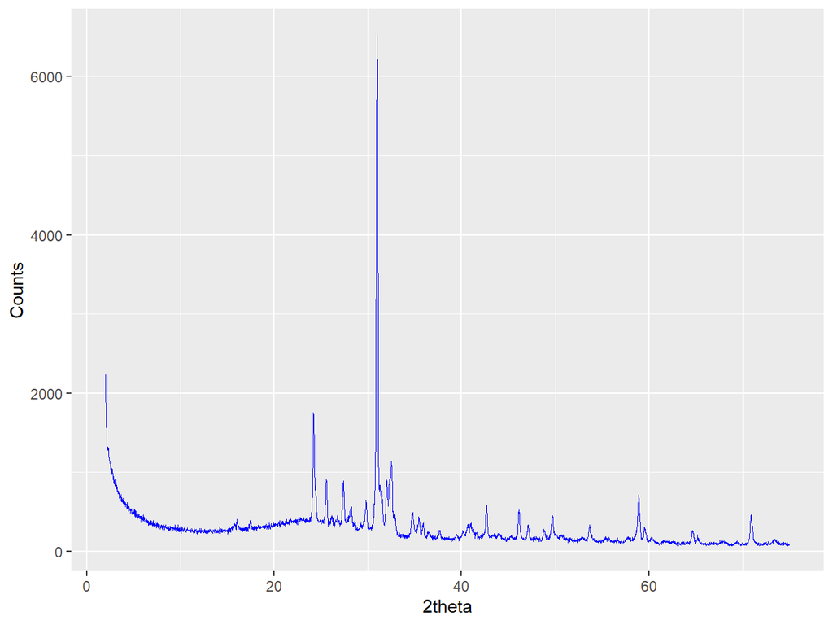

Figure 2.1: An example figure created using the plot method for an XY object.

```r
plot(xy1, wavelength = "Co", interactive = FALSE)
```

where `wavelength = "Co"` is required so that d-spacings can be computed and displayed when `interactive = TRUE`.

## 2.2 Plotting `multiXY` objects

Often it’s useful to plot more than one pattern at the same time, which can be achieved by plotting a `multiXY` object:

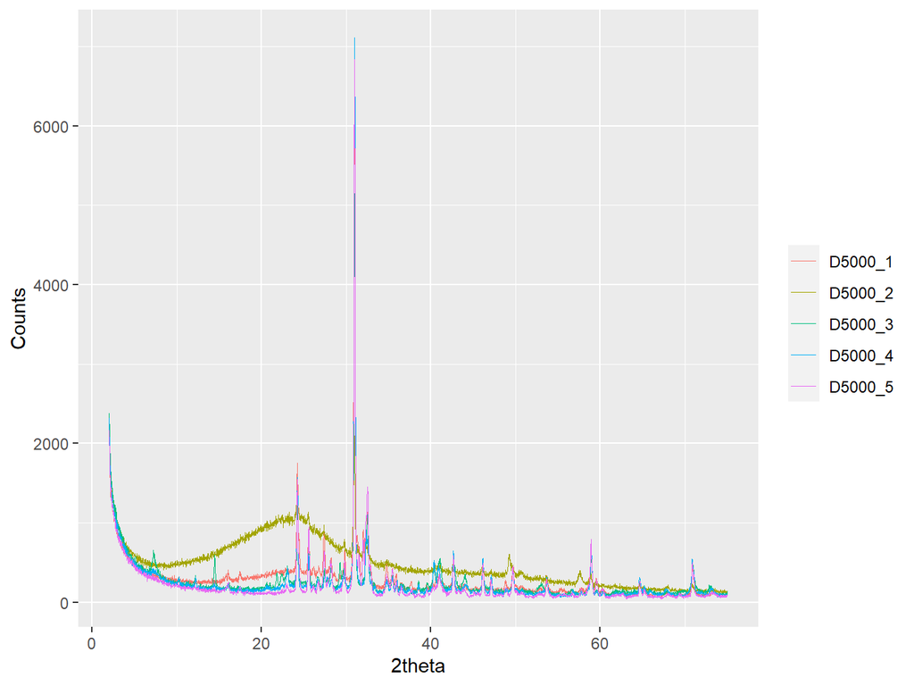

Figure 2.2: An example figure created using the plot method for a multiXY object.

```r
plot(xy_list1, wavelength = "Co")
```

As above, adding `interactive = TRUE` to the function call will produce an interactive plot. In addition, plotting of `XY` and `multiXY` objects also allows you to alter the x-axis limits and normalise the count intensities for easier comparison of specific peaks:

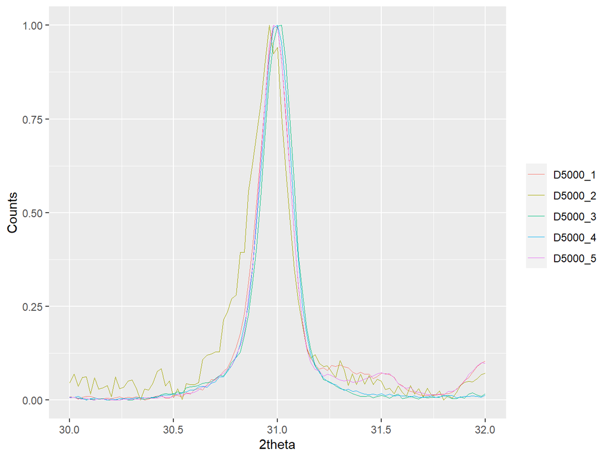

```r
plot(xy_list1, wavelength = "Co",
     xlim = c(30, 32), normalise = TRUE)
```

## 2.3 Modifying plots

All plots shown so far are produced behind the scenes using the [**ggplot2**](https://ggplot2.tidyverse.org/) package (Wickham 2016), which will already be present on your machine if you have installed **powdR**. This means that it is possible to modify the plots in different ways by adding subsequent **ggplot2** layers, each separated by `+`. For example, it’s possible to add points of the quartz peak intensities extracted from a [crystal structure database](http://rruff.geo.arizona.edu/AMS/amcsd.php) using `geom_point()`, and then add a title using `ggtitle()`, followed by changing the theme using `theme_bw()`.

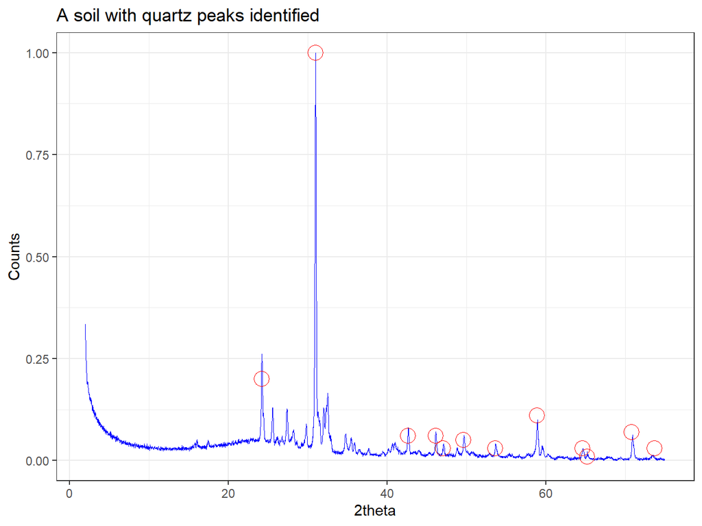

Figure 2.4: A quartz diffractogram with the locations and relative intensities of the quartz peaks identified.

```r
#Define the relative intensities of quartz peaks
quartz <- data.frame("tth" = c(24.22, 30.99, 42.61, 46.12,
                               47.06, 49.62, 53.62, 58.86,
                               64.60, 65.18, 70.79, 73.68),
                     "intensity" = c(0.20, 1.00, 0.06, 0.06,
                                     0.03, 0.05, 0.03, 0.11,
                                     0.03, 0.01, 0.07, 0.03))

#Load the ggplot2 package
library(ggplot2)

#Create a plot called p1
p1 <- plot(xy1, wav = "Co", normalise = TRUE) +
           geom_point(data = quartz, aes(x = tth, y = intensity), size = 5,
             shape = 21, colour = "red") +
           ggtitle("A soil with quartz peaks identified") +
           theme_bw()

p1
```

Further help on **ggplot2** is provided in [Hadley Wickham’s excellent documentation](https://r4ds.had.co.nz/data-visualisation.html) on data visualization.

Plots produced using **ggplot2** are static and can be exported as high quality images or pdfs. In some cases it can also be useful to produce an interactive plot, especially when minor features of XRPD data require inspection. For most plots derived from **ggplot2**, the `ggplotly()` function from the **plotly** package can be used to create such interactive plots, which will load either in RStudio or your web browser:

```r
library(plotly)

ggplotly(p1)
```

# 3 Manipulating XRPD data

[video not shown]

At this stage we have loaded XRPD data into R and produced plots to visualise single or multiple patterns. Loading XRPD data into R opens up almost limitless capabilities for analysing and manipulating the data via the R language and the [thousands of open source packages](https://cran.r-project.org/web/packages/available_packages_by_name.html) that enhance its functionality. Here, some useful data manipulation features of **powdR** will be introduced:

- Interpolation
- Alignment
- Converting to data frames
- 2θ transformation

## 3.1 Interpolation

Sometimes XRPD patterns within a given data set may contain a number of different 2θ axes due to the measurements being carried out on different instruments or on the same instrument but with a different set-up. Direct comparison of such data requires that they are interpolated onto the same 2θ axis.

Here a data set containing 2 samples with different 2θ axes will be created using the `soils` and `rockjock_mixtures` data that are pre-loaded within the **powdR** package:

```r
two_instruments <- as_multi_xy(list("a" = soils$granite,
                                    "b" = rockjock_mixtures$Mix2))

lapply(two_instruments, summary)
```

```
#> $a
#>       tth            counts
#>  Min.   : 4.01   Min.   :  189.0
#>  1st Qu.:20.47   1st Qu.:  282.5
#>  Median :36.94   Median :  367.0
#>  Mean   :36.94   Mean   :  544.3
#>  3rd Qu.:53.40   3rd Qu.:  543.5
#>  Max.   :69.85   Max.   :20316.5
#>
#> $b
#>       tth         counts
#>  Min.   : 5   Min.   :  30.0
#>  1st Qu.:20   1st Qu.:  67.0
#>  Median :35   Median :  90.0
#>  Mean   :35   Mean   : 126.3
#>  3rd Qu.:50   3rd Qu.: 137.0
#>  Max.   :65   Max.   :1234.0
```

In this example, the data within the `two_instruments` list will be interpolated onto an artificial 2θ axis called `new_tth`, which ranges from 10 to 60 degrees 2θ with a resolution of 0.02:

```r
new_tth <- seq(10, 60, 0.02)

two_instruments_int <- interpolate(two_instruments, new_tth)

lapply(two_instruments_int, summary)
```

```
#> $a
#>       tth           counts
#>  Min.   :10.0   Min.   :  191.6
#>  1st Qu.:22.5   1st Qu.:  325.7
#>  Median :35.0   Median :  419.8
#>  Mean   :35.0   Mean   :  617.5
#>  3rd Qu.:47.5   3rd Qu.:  610.4
#>  Max.   :60.0   Max.   :20283.4
#>
#> $b
#>       tth           counts
#>  Min.   :10.0   Min.   :  32.0
#>  1st Qu.:22.5   1st Qu.:  66.0
#>  Median :35.0   Median :  87.0
#>  Mean   :35.0   Mean   : 130.1
#>  3rd Qu.:47.5   3rd Qu.: 137.0
#>  Max.   :60.0   Max.   :1234.0
```

## 3.2 Alignment

Peak positions in XRPD data commonly shift in response to small variations in specimen height in the instrument. Even seemingly small misalignments between peaks can hinder the analysis of XRPD data. One approach to deal with such peak shifts is to use a mineral with essentially invariant peak positions as an internal standard, resulting in well aligned data by adding or subtracting a fixed value to the 2θ axis.

The **powdR** package contains functionality for aligning single or multiple patterns using the `align_xy()` function. In the following examples, samples will be aligned to a pure quartz pattern that will be loaded from the **powdR** package using `read_xy()`

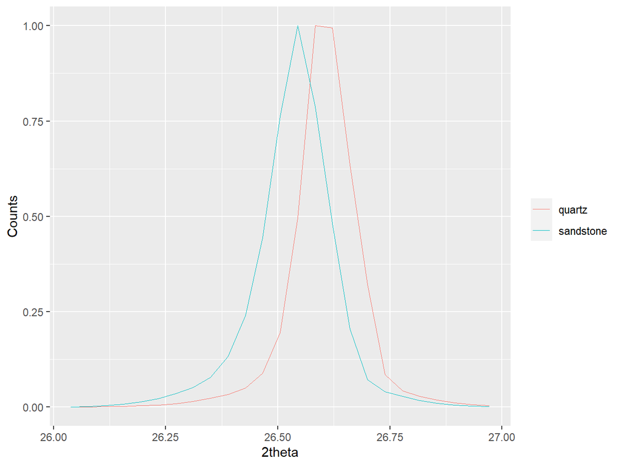

Figure 3.1: Unaligned diffractograms.

```r
#Extract the location of the quartz xy file
quartz_file <- system.file("extdata/minerals/quartz.xy", package = "powdR")

#load the file
quartz <- read_xy(quartz_file)

#Plot the main quartz peak for pure quartz and a sandstone-derived soil
plot(as_multi_xy(list("quartz" = quartz,
                      "sandstone" = soils$sandstone)),
     wavelength = "Cu",
     normalise = TRUE,
     xlim = c(26, 27))
```

As shown in the figure above, the main quartz peaks of these two diffraction patterns do not align. This can be corrected using `align_xy()`:

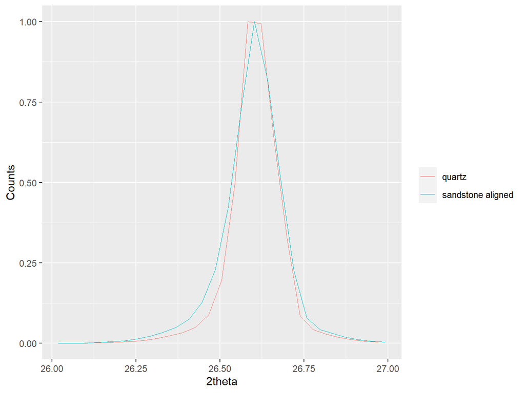

Figure 3.2: Aligned diffractograms.

```r
#Align the sandstone soil to the quartz pattern
sandstone_aligned <- align_xy(soils$sandstone, std = quartz,
                              xmin = 10, xmax = 60, xshift = 0.2)

#Plot the main quartz peak for pure quartz and a sandstone-derived soil
plot(as_multi_xy(list("quartz" = quartz,
                      "sandstone aligned" = sandstone_aligned)),
     wavelength = "Cu",
     normalise = TRUE,
     xlim = c(26, 27))
```

In cases where multiple patterns require alignment to a given standard, `align_xy()` can also be applied to `multiXY` objects:

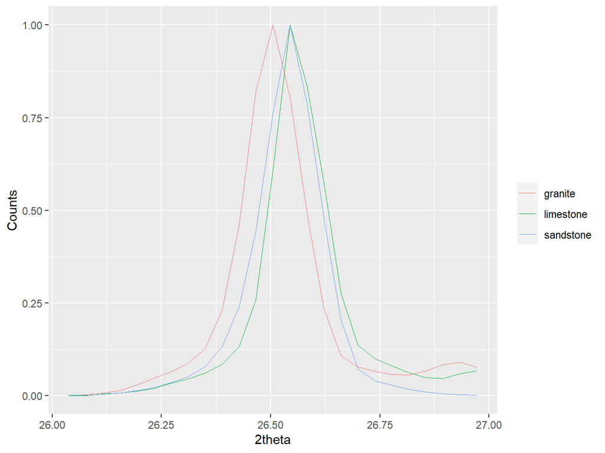

Figure 3.3: Unaligned diffractograms in a multiXY object.

```r
#Plot the unaligned soils data to show misalignments
plot(soils, wav = "Cu",
     xlim = c(26, 27), normalise = TRUE)
```

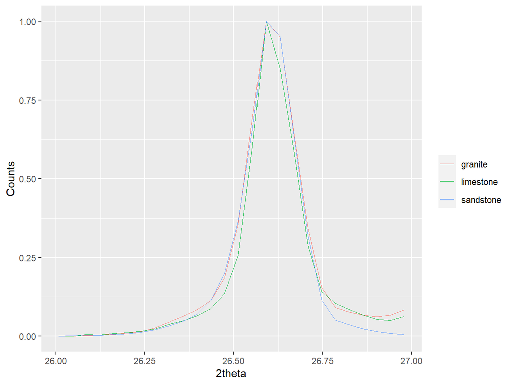

Figure 3.4: Aligned diffractograms in a multiXY object.

```r
#Align the sandstone soil to the quartz pattern
soils_aligned <- align_xy(soils, std = quartz,
                          xmin = 10, xmax = 60, xshift = 0.2)

#Plot the main quartz peak for pure quartz and a sandstone-derived soil
plot(soils_aligned,
     wavelength = "Cu",
     normalise = TRUE,
     xlim = c(26, 27))
```

## 3.3 Converting to and from data frames

`multiXY` objects can be converted to data frames using the `multi_xy_to_df()` function. When using this function, all samples within the `multiXY` object must be on the same 2θ axis, which can be ensured using the `interpolate()` function outlined above.

```r
#Convert xy_list1 to a dataframe
xy_df1 <- multi_xy_to_df(xy_list1, tth = TRUE)

#Show the first 6 rows of the derived data frame
head(xy_df1)
```

```
#>    tth D5000_1 D5000_2 D5000_3 D5000_4 D5000_5
#> 1 2.00    2230    2334    2381    2323    2169
#> 2 2.02    2012    2222    2297    2128    2021
#> 3 2.04    1950    2031    2211    2056    1929
#> 4 2.06    1828    1972    2077    1918    1823
#> 5 2.08    1715    1896    2000    1861    1757
#> 6 2.10    1603    1701    1868    1799    1673
```

In cases where the 2θ column is not required, the use of `tth = FALSE` in the function call will result in only the count intensities being included in the output. Data frames that do contain the 2θ column can be converted back to `multiXY` objects using `as_multi_xy`:

```r
#Convert xy_df1 back to a list
back_to_list <- as_multi_xy(xy_df1)

#Show that the class is now multiXY
class(back_to_list)
```

```
#> [1] "multiXY" "list"
```

## 3.4 2θ transformation

Laboratory XRPD data are usually collected using either Cu or Co X-ray tubes, which each have characteristic Kα wavelengths (e.g. Cu-Kα = 1.54056 Angstroms whereas Co-Kα = 1.78897 Angstroms). These wavelengths determine the 2θ at which the conditions for diffraction are met via Bragg’s Law:

$$\begin{aligned}
n\lambda = 2d\sin\theta
\end{aligned}$$

where $n$ is an integer describing the diffraction order, $\lambda$ is the wavelength (Angstroms) and $d$ is the atomic spacing (Angstroms).

In some instances it can be useful to transform the 2θ axis of a given sample so that the 2θ peak positions are representative of a measurement made using a different X-ray source. This can be achieved using the `tth_transform()` function:

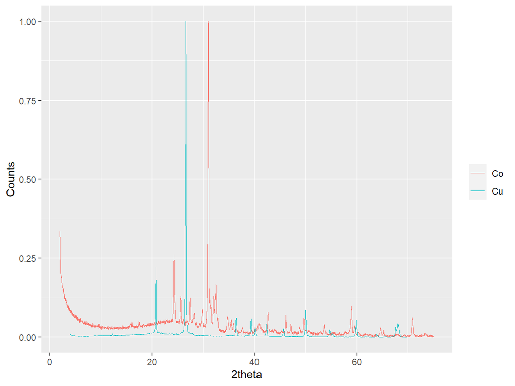

Figure 3.5: Data obtained from Co and Cu X-ray tubes prior to 2theta transformation.

```r
#Create a multiXY object for this transform example
transform_eg <- as_multi_xy(list("Co" = xy_list1$D5000_1,
                                 "Cu" = soils$sandstone))

#Plot two patterns recorded using different wavelengths
plot(transform_eg,
     wavelength = "Cu",
     normalise = TRUE,
     interactive = FALSE)
```

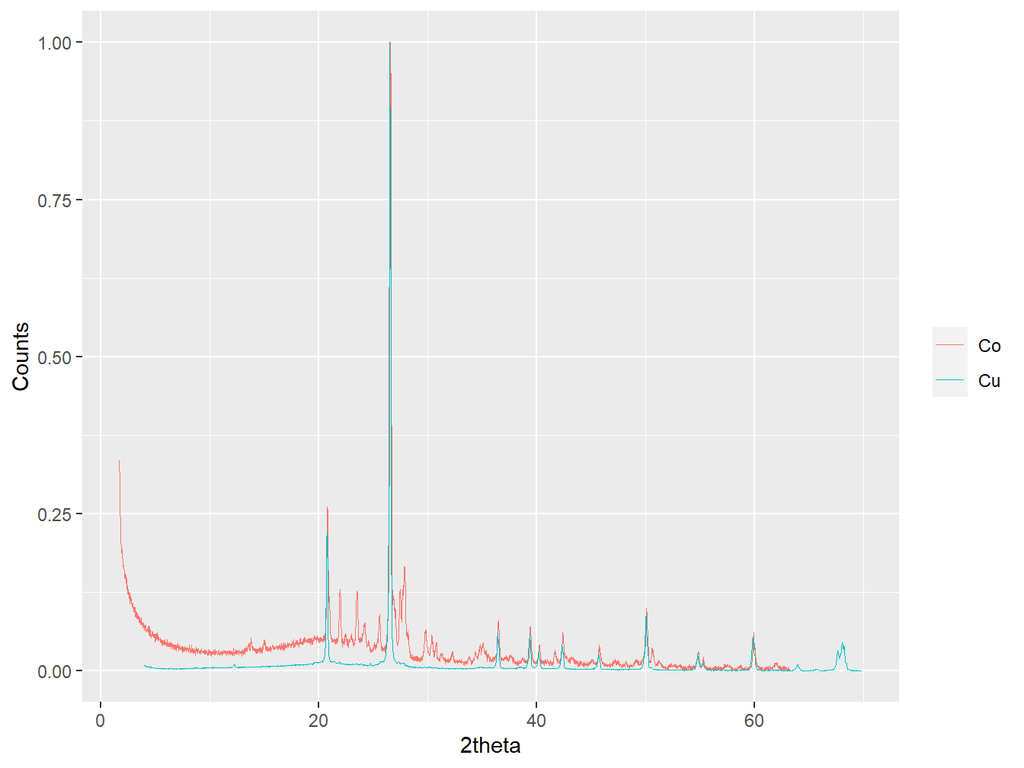

```r
#transform the 2theta of the "Co" sample to "Cu"
transform_eg$Co$tth <- tth_transform(transform_eg$Co$tth,
                                     from = 1.78897,
                                     to = 1.54056)

#Replot data after transformation
plot(transform_eg,
     wavelength = "Cu",
     normalise = TRUE,
     interactive = FALSE)
```

Note how prior to the 2θ transformation, the dominant peaks in each pattern (associated with quartz in both cases) do not align. After the 2θ transformation the peaks are almost aligned, with a small additional 2θ shift that could be computed using the `align_xy()` function outlined above. Whilst Cu and Co are the most common X-ray sources for laboratory diffractometers, `tth_transform()` can accept any numeric wavelength value.

# References

Kreutzer, Sebastian, and Johannes Friedrich. 2020. *Rxylib: Import XY-Data into r*. https://CRAN.R-project.org/package=rxylib.

Wickham, Hadley. 2016. *Ggplot2: Elegant Graphics for Data Analysis*. Springer-Verlag New York. https://ggplot2.tidyverse.org.